# Ford GoBike System Data Exploration

## by Siqi Wan

## Investigation Overview

Overall goal is to communicate and share the findings from Ford GoBike system data.

## Dataset Overview

This dataset is Bay Wheels's trip data for public use. This data is provided according to the Bay Wheels License Agreement. The dataset including bike rental trip information and contains data 2017-2020/03

## Trip Duration distribution

#### From the trip duration distribution we can see:

```
The average trip duration: 677.4310671552856
The median trip duration: 562.0
```

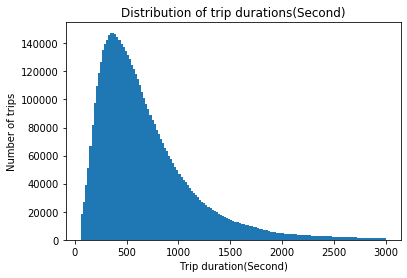

```python
p = plt.hist(less_than_3k['duration_sec'], bins = np.arange(60, less_than_3k['duration_sec'].max() + 1, 20))
xlabel = plt.xlabel('Trip duration(Second)')
ylabel = plt.ylabel('Number of trips')
title = plt.title('Distribution of trip durations(Second)')
print("The average trip duration: " + str(less_than_3k['duration_sec'].mean()))
print("The median trip duration: " + str(less_than_3k['duration_sec'].median()))
```

## Trip Duration distribution among different user types - suscriber vs customer.

#### From above distribution we observed:

1. Subscribers and customer trip duration distribution are all right skewed with majority trip duration around 500 seconds.
2. Our dataset has more subscriber data points compares to customer data points.
3. With the trip duration increase, the delta between number of trips for subscriber vs customer is not obvious anymore. This could because: a. lack of data(less than 5000 records) b. it is also possbile that for users that trips more than 1500 seconds, there is not difference in the number of subscriber trips and customer trips.

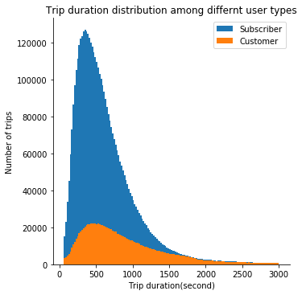

```python
# Plot distribution among different user types
g = sb.FacetGrid(data = less_than_3k, hue = 'user_type',height = 5)
bins = np.arange(60, less_than_3k['duration_sec'].max() + 1, 20)
p = g.map(plt.hist,'duration_sec',bins = bins)
legend = plt.legend()
xlabel = plt.xlabel('Trip duration(second)')
ylabel = plt.ylabel('Number of trips')
title = plt.title('Trip duration distribution among differnt user types')
```

## When are most trips taken in terms of time of day, day of the week, or month of the year?

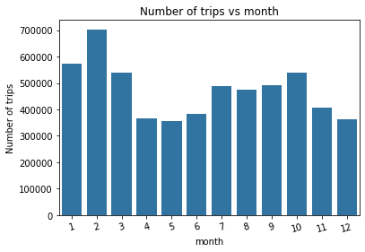

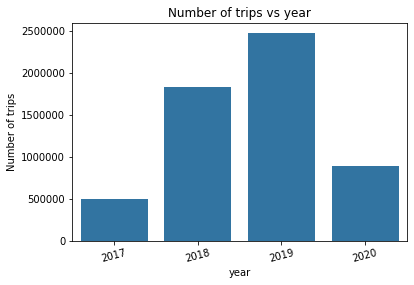

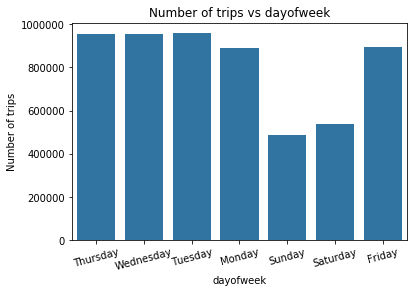

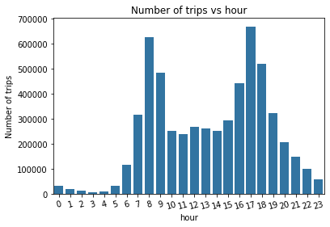

```python
column_list = ['month','year','dayofweek','hour']
for i in column_list:
    base_color = sb.color_palette()[0]
    p = sb.countplot(data=less_than_3k, x = i ,color = base_color)
    title = plt.title('Number of trips vs ' + i)
    ylabel = plt.ylabel('Number of trips')
    xticks = plt.xticks(rotation=15)
    plt.show()
```